# Overview

# Kristiana Reed's Portfolio

MS in Data Science with strong analytical skills, ready to help you find actionable insights in the murkeiest of data!

[👥 LinkedIn](https://www.linkedin.com/in/kristiana-reed) 📄 Download Resume

## About Me

Data scientist with a passion for turning complex datasets into clear, actionable insights. Proficient in R and statistical modeling, with hands-on experience in machine learning, data visualization, and exploratory analysis. My initial background is in physics and astronomy, but my postgraduate experience is in data analysis using artificial intelligence and machine learning and the creation of said algorithms. Proficient in both R and Python, I easily adapt to any working environment. Most of my career has been focused on website performance and SEO consultation, although I easily adapt to data related to a wide variety of enviornments.

R Python SQL tidyverse dplyr plotly TensorFlow R Markdown REST API Statistical Modeling Regression Analysis GAM Machine Learning Predictive Modeling Anomaly Detection Exploratory Data Analysis Data Visualization Data Wrangling Automation SEO Web Analytics

Projects

3 projects · Data Analysis & Machine Learning

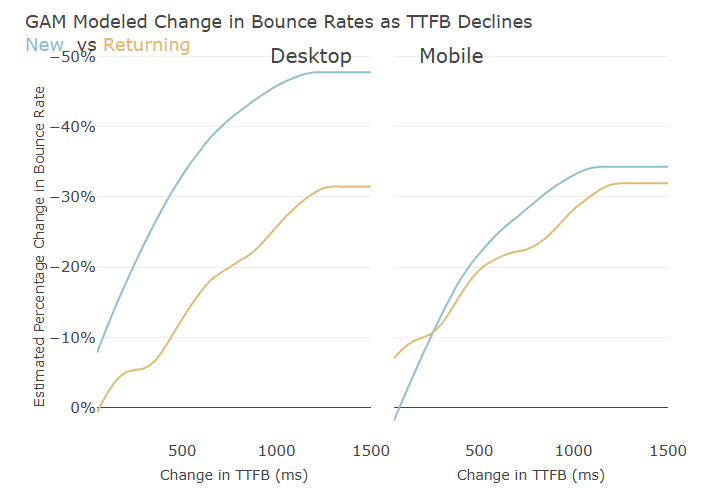

Machine Learning

##### Bounce Rate and TTFB Correlation

📈 Quantified actionable TTFB targets to drive measurable bounce rate reductions

Using a GAM to answer: "If TTFB improves by x milliseconds, how much will bounce rate improve?"

R GAM ggplot2 Regression Analysis Predictive Modeling Web Analytics SEO

View Project [View Code](https://github.com/PlaidDragon/Portfolio)

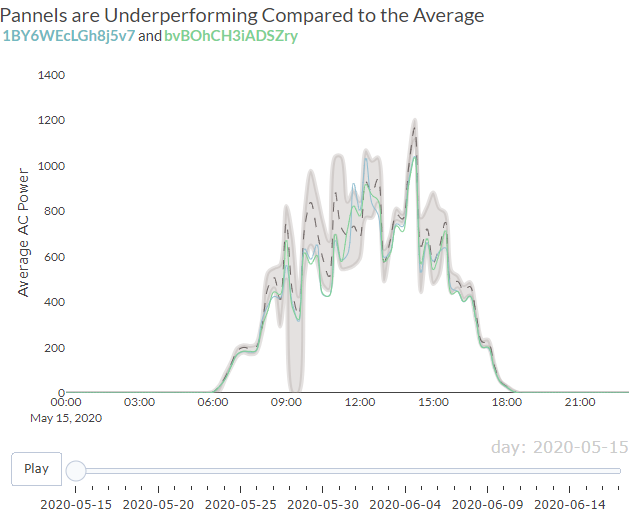

Data Analysis

##### Solar Power Plant Monitoring

⚡ Identified underperforming panels and flagged maintenance needs across the plant

Evaluate performance of solar panel power generation to identify maintenance needs and potential issues.

R ggplot2 tidyverse Time Series Anomaly Detection Exploratory Data Analysis

View Project [View Code](https://github.com/PlaidDragon/Portfolio)

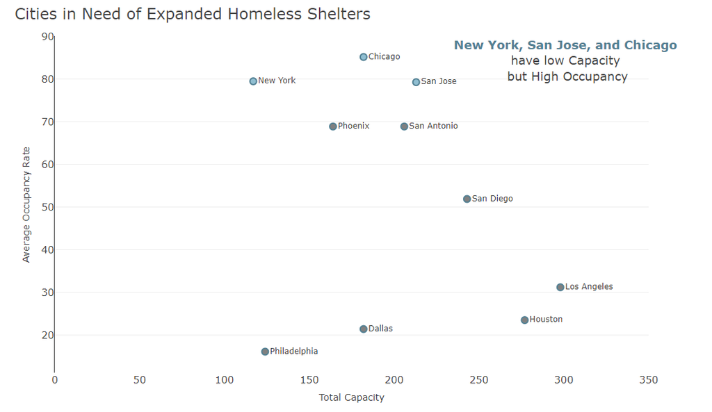

Data Analysis

##### Sheltering the Homeless

🏠 Ranked shelters by occupancy stress to support resource allocation decisions

An analysis identifying which shelters are under the most occupancy stress.

R ggplot2 dplyr Data Wrangling Exploratory Data Analysis Statistical Modeling

View Project [View Code](https://github.com/PlaidDragon/Portfolio)

[LinkedIn](https://www.linkedin.com/in/kristiana-reed) plaiddragon@rocketmail.com

© 2026 Kristiana Reed